# Métodos Computacionais - Semana 4

Otimização Numérica I

Hudson Torrent

2021/1

## Otimização Numérica

- Vamos iniciar estudando otimização numérica.
- Posteriormente, estudaremos otimização estocástica.
- A otimização numérica é altamente dependente das propriedades analíticas da função objetivo.
- Essas propriedades são menos importantes em abordagens baseadas em simulação.
- Se a função objetivo, $h$, é complexa demais para permitir o estudo analítico ou se o domínio $\theta$ é muito irregular a abordagem de otimização estocástica é mais indicada.

## Método de Newton

- Vamos iniciar nosso estudo com o método de Newton-Raphson para obter a raiz de uma equação. Ou seja, queremos encontrar $x$ tal que $f(x)=0$.
- Seja $f$ uma função diferenciável. A expansão de Taylor nos diz que uma boa aproximação para $f(x_1)$ ao redor de $x_0$ é dada por:
  $$f(x_1) = f(x_0) + f'(x_0)(x_1-x_0) + resto$$
- Suponha que $f(x_1)=0$, então:
  $$x_1 = x_0 - \frac{f(x_0)}{f'(x_0)}$$
- Podemos usar o método de Newton-Raphson para resolver uma equação do tipo $f(x) = \alpha$.

#### Exercício 1

> Seja $X \sim N(0,1)$. Dado um valor $\alpha \in (0,1)$, o percentil de nível $\alpha$ é o valor que soluciona a equação $F(x_{\alpha}) = \alpha$. Encontre o percentil de nível 0.025 para a distribuição $N(0,1)$ usando o método de Newton-Raphson. Note que $F(x_{\alpha}) - \alpha = 0$.

#### Resolução do exercício 1

```r
set.seed(1234)

cc <- 1
conta <- 0
a <- 0.025

x0 <- 0  # valor inicial

while (cc > 0.00001) {
  x1 <- x0 - (pnorm(x0) - a) / dnorm(x0)
  cc <- (x1 - x0)^2
  x0 <- x1
  conta <- conta + 1
}

print(x1)
```

```
## [1] -1.959964
```

```r
qnorm(a)  # valor função pronta do R.
```

```
## [1] -1.959964
```

- Podemos estar interessados em
  $$\max_{x \in \chi} h(x)$$
- O Método de Newton também se aplica aqui, pois, supondo $h$ 2 vezes diferenciável e que o máximo seja um ponto interior de $\chi$, de fato, queremos encontrar $x$ tal que $h'(x)=0$. Nesse caso, a expansão de Taylor será aplicada a $h'$ e não a $h$.
  $$h'(x_1) = h'(x_0) + h''(x_0)(x_1-x_0) + resto$$
- Portanto, a solução é dada por:
  $$x_1 = x_0 - \frac{h'(x_0)}{h''(x_0)}$$

#### Exercício 2

> Seja $h(x) = -x^2+2x-5$ para $x \in (-2,4)$. Encontre o valor $x$ que maximiza $h$.

> Seja $h(x) = x^2-2x-5$ para $x \in (-2,4)$. Encontre o valor $x$ que minimiza $h$.

#### Resolução do exercício 2

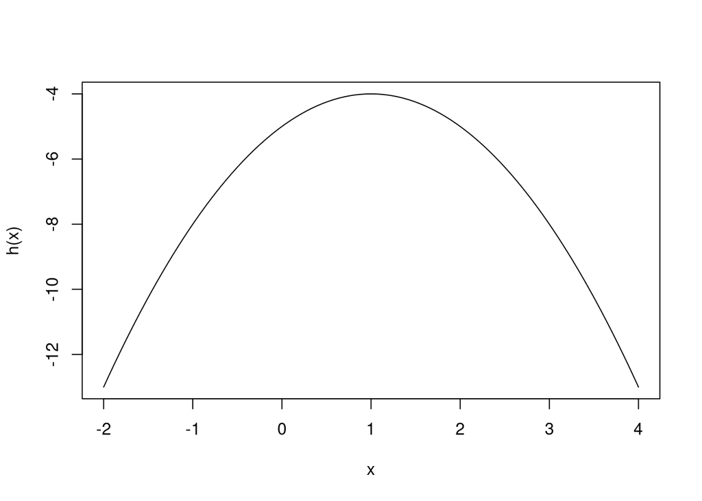

```r
h <- function(x) -x^2 + 2 * x - 5
h1 <- function(x) -2 * x + 2
h2 <- function(x) -2

curve(h, -2, 4)
```

```r
set.seed(1234)

cc <- 1
conta <- 0
x0 <- -1.5 # importante variar o chute inicial

while (cc > 0.0001) {
  x1 <- x0 - h1(x0) / h2(x0)
  cc <- (x1 - x0)^2
  x0 <- x1
  conta <- conta + 1
}
print(x1)
```

```
## [1] 1
```

## Limitações do Método de Newton

- O método encontra um $x$ que soluciona a equação $f(x)=0$.
- O método funciona bem se a equação tiver uma única solução, caso contrário, o valor obtido dependerá fortemente do valor inicial utilizado. Por outro lado, isso pode ser usado para se encontrar múltiplas raízes de uma equação.
- Pode não ocorrer a convergência. Geralmente, se o valor inicial não for suficientemente próximo da solução, o método falhará.

#### Código exemplo

```r
f <- function(x) 5 * sin(5 * x) + cos(x)
fl <- function(x) 25 * cos(5 * x) - sin(x)
fl2 <- function(x) -25 * 5 * sin(5 * x) - cos(x)

curve(f,-1,1)

set.seed(1234)

cc <- 1
conta <- 0
#x0 <- -0.7 # desce para minimo local
x0 <- -0.8 # sobe para maximo local

while (cc > 0.0001) {
  x1 <- x0 - fl(x0) / fl2(x0)
  cc <- (x1 - x0)^2
  x0 <- x1
  conta <- conta + 1
}
print(x1)
```

```
## [1] -0.936035
```

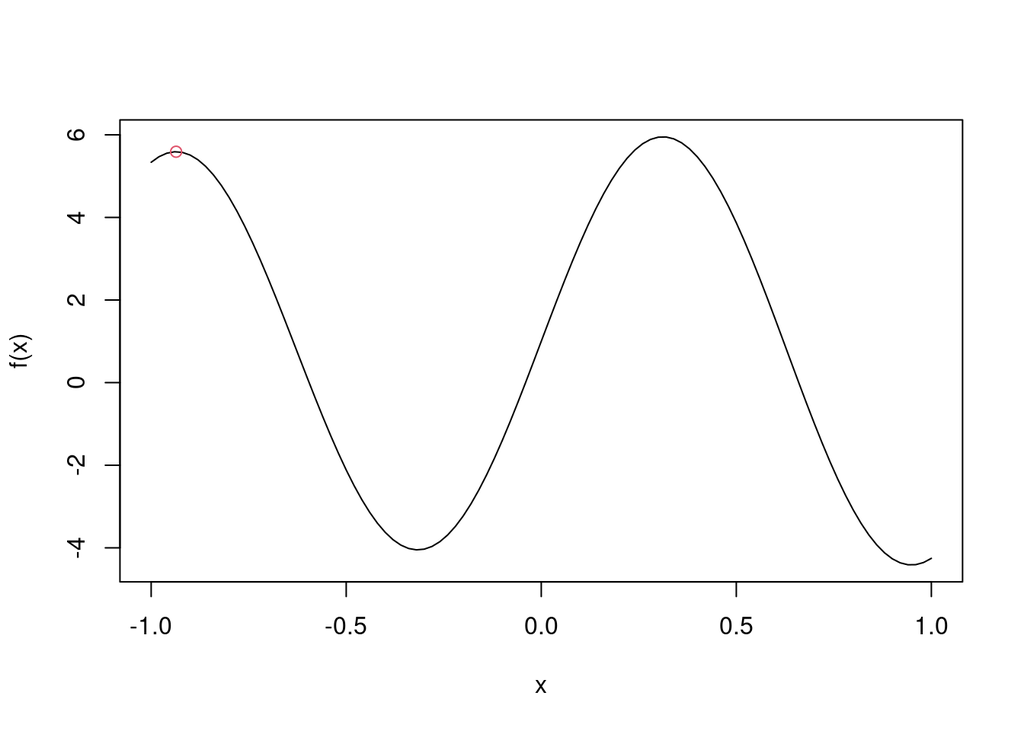

```r
points(x1, f(x1), col = 2)
```

## Método de Newton-Raphson - caso multivariado

- Nosso interesse agora é
  $$\max_{\vec{x} \in \boldsymbol{\chi}} h(\vec{x}), \ \text{onde} \ \vec{x} = (x_1,\cdots,x_p)'$$
- A manipulação da expansão de Taylor no caso multivariado resulta em:
  $$\vec{x}_1 = \vec{x}_0 - \left[ H(\vec{x}_0) \right]^{-1} \boldsymbol{s}(\vec{x}_0),$$
- $\vec{x}$ é um vetor $p \times 1$.
- $\boldsymbol{s}(\vec{x})' = \nabla h(\vec{x}) = \partial h(\vec{x})/\partial x_1, \cdots, \partial h(\vec{x})/\partial x_p$. Ou seja, $\boldsymbol{s}(\vec{x})$ é o vetor $p \times 1$ igual ao vetor gradiente transposto, também chamado de da função objetivo $h$.
- $H(\vec{x})$ é a matriz hessiana da função objetivo, ou seja, a matriz de derivadas de segunda ordem $H(\vec{x}) = \partial^2 h(\vec{x})/ \partial \vec{x} \partial \vec{x}'$.

## Método de Newton-Raphson

- No ponto $\vec{x}^*$, $\boldsymbol{s}(\vec{x}^*)=\vec{0}$.
- Se o problema for de maximização, é importante, para o método funcionar corretamente, que a matriz hessiana seja uma matriz negativa definida.
- Se o problema for de minimização, é importante, para o método funcionar corretamente, que a matriz hessiana seja uma matriz positiva definida.
- Para um particular valor de $\vec{x}$, durante o processo de otimização, pode acontecer das condições acima não serem satisfeitas, fazendo que o processo caminhe numa direção incorreta.

#### Exercício 3

> Encontre o ponto $(x,y)$ que minimiza $h(x,y)=x^2+5y^2$, usando o método de Newton-Raphson.

#### Resolução exercício 3 - olhando a função

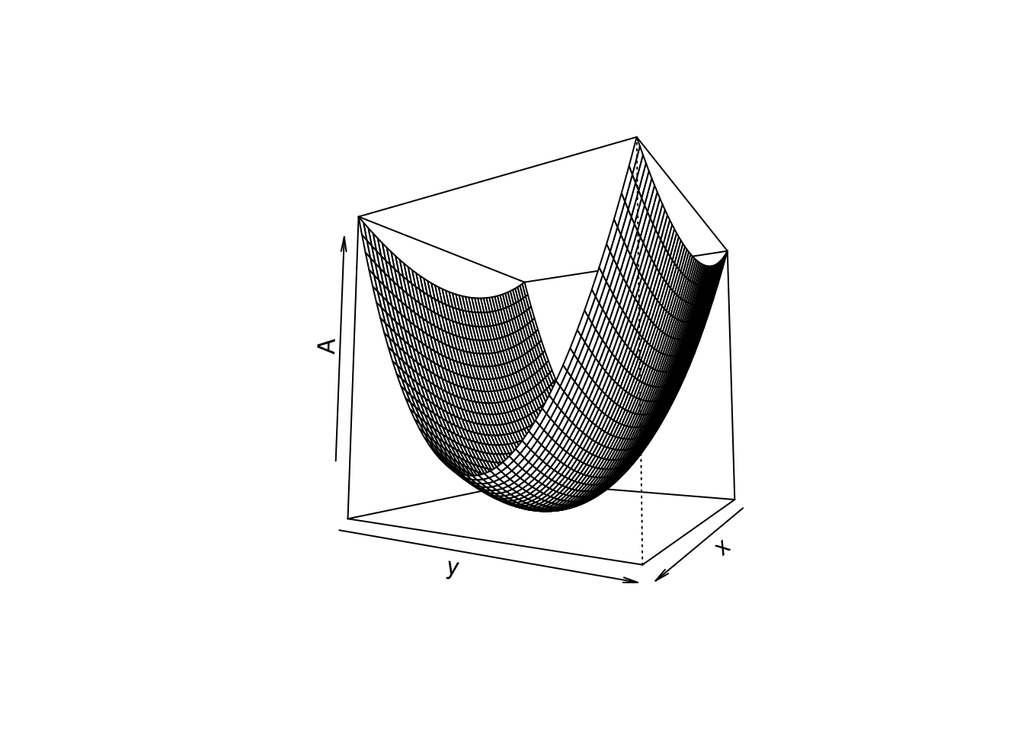

```r
f <- function(x, y) (x^2 + 5 * y^2)
x <- y <- seq(from = -3, to = 3, length = 50)
A <- matrix(0, nrow = 50, ncol = 50)
for (i in 1:50) {
  A[i,] <- f(x[i], y)
}
persp(x, y, A, theta = 120, phi = -5)
```

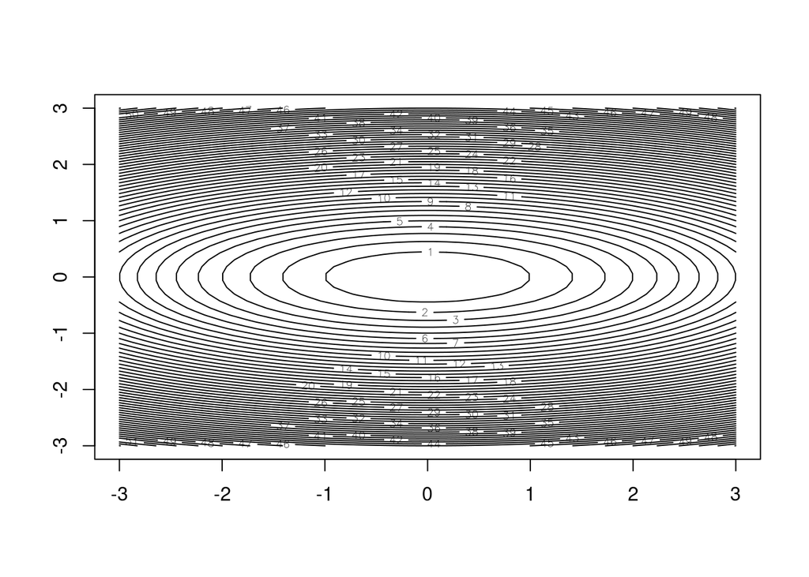

```r
contour(x, y, A, nlevels = 50)
```

#### Resolução exercício 3 - Construindo score e matriz hessiana

```r
f <- function(x, y) x^2 + 5 * y^2
f1 <- function(z) {
  x <- z[1]
  y <- z[2]
  rbind(2*x,10*y)
}

f2 <- function(z){
  A <- matrix(0,ncol=2,nrow=2)
  A[1,1] <- 2
  A[1,2] <- A[2,1] <- 0
  A[2,2] <- 10
  return(A)
}
```

#### Resolucão exercício 3

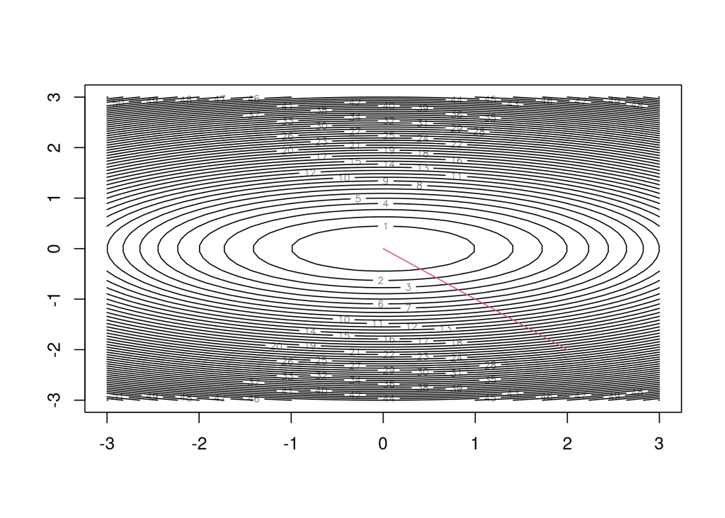

```r
set.seed(1234)

cc <- 1
conta <- 0
z <- x0 <- rbind(2, -2)

while (cc > 0.0001) {
  x1 <- x0 - solve(f2(x0)) %*% (f1(x0))
  cc <- sum((x1 - x0)^2)
  x0 <- x1
  conta<-conta + 1
  z <- cbind(z, x1)
}
rownames(z) <- paste("x", seq_len(nrow(x0)), sep = "")
colnames(z) <- paste("i", seq_len(conta + 1),sep = "")
contour(x, y, A, nlevels = 50)
lines(z[1, ], z[2, ], col = 2)
```

#### Exercício 4

> Encontre o ponto $(x,y)$ que minimiza $h(x,y)=x^4+y^2$, usando o método de Newton-Raphson.

#### Resolução do exercício 4

Precisamos modificar apenas a seguinte parte na rotina anterior:

```r
f <- function(x, y) x^4 + y^2
f1 <- function(z) {
  x <- z[1]
  y <- z[2]
  rbind(4 * x^3, 2 * y)
}

f2 <- function(z) {
  A <- matrix(0, ncol = 2, nrow = 2)
  A[1, 1] <- 12 * x^2
  A[1, 2] <- A[2, 1] <- 0
  A[2, 2] <- 2
  return(A)
}
```

#### Exercício 5

> Construa uma função que faça o algoritmo de Newton-Raphson. Use como argumentos dessa função a primeira e a segunda derivadas da função objetivo, um vetor de valores iniciais e demais variáveis da função objetivo. Sua função deve retornar o vetor com os valores que otimizam a função objetivo.

#### Resolução exercício 5

```r
nr.optim <- function(x0, f1, f2, ...) {
  cc <- 1
  conta <- 0
  x0 <- matrix(x0, ncol = 1)
  z <- x0

  while (cc > 0.0001) {
    x1 <- x0 - solve(f2(x0, ...)) %*% (f1(x0, ...))
    cc <- sum((x1 - x0)^2)
    x0 <- x1
    conta <- conta + 1
    z <- cbind(z, x1)
  }
  rownames(z) <- paste("x", seq_len(nrow(x0)), sep = "")
  colnames(z) <- paste("i", seq_len(conta + 1), sep = "")

  return(
    list(
      arg.ot = x0,
      seq.ot = z
    )
  )
}
```

## Uma aplicação - MQO

- Suponha uma sequência de pares de v.a.’s $iid$ $(X_1,Y_1),\cdots,(X_n,Y_n)$ que se relacionam através do modelo $Y_i = \beta_0 + \beta_1 X_i + \epsilon_i$, $i=1,\cdots,n$. Ou seja, $Y$ é uma igual a um função linear de $X$ mais um erro estocástico.
- Suponha que uma amostra $(x_i,y_i)_{i=1}^n$ seja observada. Deseja-se estimar $\beta_0$ e $\beta_1$ de modo a minimizar $\sum_{i=1}^n \epsilon_i^2$. Ou seja, queremos encontrar $\beta$’s que minimizam a soma dos quadrados dos .

#### Exercício 6

> 1. Simular o modelo $Y_i = \beta_0 + \beta_1 X_i + \epsilon_i$, $i=1,\cdots,n$, onde $n = 200$, $\epsilon \sim N(0,1)$, $\beta_0 = 2$, $\beta_1=5$ e $X \sim U_{[-1,1]}$.
> 2. Encontrar, via método de Newton-Raphson, $\beta_0$ e $\beta_1$ que minimizam $\sum_{i=1}^n \epsilon_i^2$ para uma particular amostra gerada no item anterior.

#### Resolução exercício 6

- Item 1:

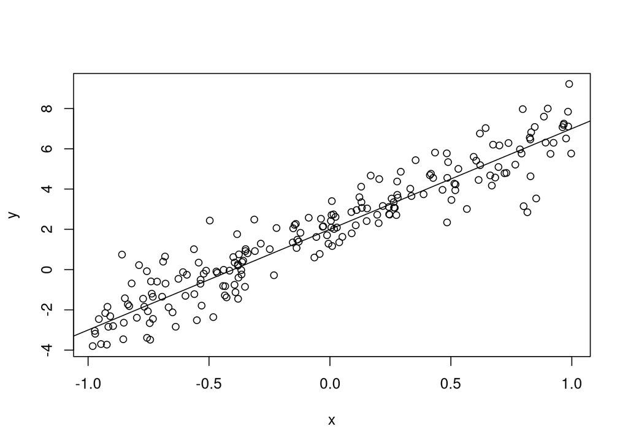

```r
n <- 200
x <- runif(n, -1, 1)
e <- rnorm(n)
y <- 2 + 5 * x + e

plot(x, y)
abline(a = 2, b = 5)
```

#### Resolução exercício 6

- Item 2:

```r
f <- function(b0, b1) sum((y - b0 - b1 * x)^2)

f1 <- function(z) {
  b0 <- z[1]
  b1 <- z[2]
  rbind(-2 * sum(y - b0 - b1 * x), -2 * sum((y - b0 - b1 * x) * x))
}

f2 <- function(z) {
  A <- matrix(0, ncol = 2, nrow = 2)
  A[1, 1] <- 2 * n
  A[1, 2] <- A[2, 1] <- 2 * sum(x)
  A[2, 2] <- 2 * sum(x^2)
  return(A)
}

reg.opt <- nr.optim(x0 = c(0, 0), f1, f2)

print(reg.opt)
```

```
## $arg.ot
##          [,1]
## [1,] 2.095135
## [2,] 4.916586
##
## $seq.ot
##    i1       i2       i3
## x1  0 2.095135 2.095135
## x2  0 4.916586 4.916586
```

- O exemplo aqui é ilustrativo, no sentido de que as soluções analíticas para $\beta_0$ e $\beta_1$ que minimizam $\sum_{i=1}^n \epsilon_i^2$ podem ser encontradas facilmente. De fato,

$$\begin{align}
\hat \beta_0 &= \overline{Y} - \hat \beta_1 \overline{X}; \\
\hat \beta_1 &= \frac{\sum_{i = 1}^{n}(X_i - \overline{X})Y_i}{\sum_{i = 1}^{n}(X_i - \overline{X})^2}
\end{align}$$

- No exemplo,

```r
b1_hat <- sum((x - mean(x)) * y) / sum((x - mean(x))^2)

b0_hat <- mean(y) - b1_hat * mean(x)

print(c(b0_hat, b1_hat))
```

```
## [1] 2.095135 4.916586
```

- Em muitos casos, o algoritmo Newton-Raphson não conduzirá à resposta exata, como nos exemplos que vimos aqui.
- A excelente performance do algoritmo nos exemplos acima se deve a expressões convenientes para a matriz Hessiana. Veremos mais detalhes a respeito na semana seguinte.